# fft_python

#### Raghav K. Chhetri

07-21-2021

- The Discrete Fourier Transform (DFT) is a way to transform a signal from time domain to frequency domain using the sum of a sequence of sine waves
- The Fast Fourier Transform (FFT) is an algorithm to calculate the DFTs efficiently by taking advantage of the symmetry properties in DFT
- [2D FFT speed test](https://thomasaarholt.github.io/fftspeedtest/fftspeedtest.html) shows `torch.fft` as the the fastest option

Multiple options exist:

1. `numpy.fft`
2. `cupy.fft` (NVIDIA's library that evaluates FFTs on GPUs)
3. `scipy.fftpack`
4. `pyfftw`
5. `torch.FFT`
- `scipy.fftpack` is slightly faster than `numpy.fft`, so using that in this notebook

```python
import sys
print('Environment: {}'.format(sys.exec_prefix))
print('Executable: {}'.format(sys.executable))
print('Version: {}'.format(sys.version))
```

```
Environment: C:\Users\Raghav\anaconda3\envs\fourier
Executable: C:\Users\Raghav\anaconda3\envs\fourier\python.exe
Version: 3.9.4 (default, Apr  9 2021, 11:43:21) [MSC v.1916 64 bit (AMD64)]
```

```python
import numpy as np
#from numpy.fft import fft, ifft

import scipy.misc
from scipy import ndimage, signal
from scipy.fftpack import fft, ifft
from scipy.fftpack import fft, ifft, fftn, ifftn, fftshift # 1D FFT and nD FFT in Scipy
# Note: fft2 is just fftn with a different default for axes

import skimage
from skimage.data import camera, gravel
from skimage.filters import difference_of_gaussians, window

import matplotlib
import matplotlib.pyplot as plt
plt.style.use('seaborn-poster')
%matplotlib inline

print('numpy: {}'.format(np.__version__))
print('scipy: {}'.format(scipy.__version__))
print('skimage: {}'.format(skimage.__version__))
print('matplotlib: {}'.format(matplotlib.__version__))
```

```
numpy: 1.20.1
scipy: 1.6.2
skimage: 0.18.1
matplotlib: 3.3.4
```

### 1D FFT (for time-series data)

- Adapted from [Python Numerical Methods (2020), Chapter 24: Fourier Transform](https://pythonnumericalmethods.berkeley.edu/notebooks/chapter24.04-FFT-in-Python.html)

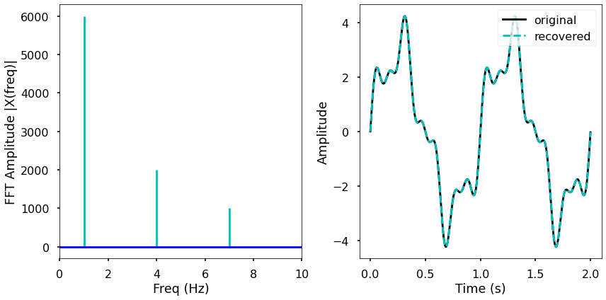

```python
srate = 2000 # Sampling rate in Hz
t = np.arange(0,2,1./srate) # Time Vector in seconds

# Signal
freq1 = 1.0
x = 3*np.sin(2*np.pi*freq1*t)

freq2 = 4.0
x += np.sin(2*np.pi*freq2*t)

freq3 = 7.0
x += 0.5* np.sin(2*np.pi*freq3*t)

# FFT of the signal
X = fft(x)
N = len(X)
n = np.arange(N)
T = N/srate
freq = n/T

plt.figure(figsize = (12, 6))
plt.subplot(121)
plt.stem(freq, np.abs(X), 'c', markerfmt=" ", basefmt="-b")
plt.xlabel('Freq (Hz)')
plt.ylabel('FFT Amplitude |X(freq)|')
plt.xlim(0, 10)

plt.subplot(122)
plt.plot(t, x, 'k',label='original')
plt.plot(t, ifft(X), 'c--',label='recovered')
plt.xlabel('Time (s)')
plt.ylabel('Amplitude')
plt.tight_layout()
plt.legend()
plt.show()
```

```python
%timeit fft(x)
```

```
70 µs ± 188 ns per loop (mean ± std. dev. of 7 runs, 10000 loops each)
```

Below, the first frequency of the signal is changed to a fraction. Now, the FFT amplitude shows up with additional frequency components

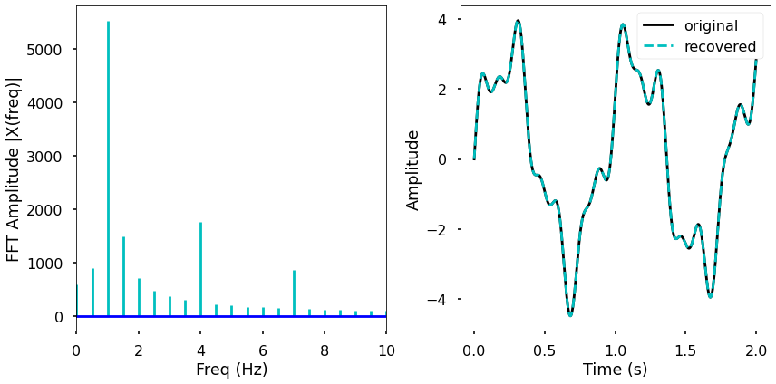

```python
srate = 2000 # Sampling rate
t = np.arange(0,2,1./srate) # Time

# Signal
freq1 = 1.1
x = 3*np.sin(2*np.pi*freq1*t)

freq2 = 4.0
x += np.sin(2*np.pi*freq2*t)

freq3 = 7.0
x += 0.5* np.sin(2*np.pi*freq3*t)

# FFT of the signal
X = fft(x)
N = len(X)
n = np.arange(N)
T = N/srate
freq = n/T

plt.figure(figsize = (12, 6))
plt.subplot(121)
plt.stem(freq, np.abs(X), 'c', markerfmt=" ", basefmt="-b")
plt.xlabel('Freq (Hz)')
plt.ylabel('FFT Amplitude |X(freq)|')
plt.xlim(0, 10)

plt.subplot(122)
plt.plot(t, x, 'k',label='original')
plt.plot(t, ifft(X), 'c--',label='recovered')
plt.xlabel('Time (s)')
plt.ylabel('Amplitude')
plt.tight_layout()
plt.legend()
plt.show()
```

These additional frequency components can be avoided by collecting the signal for a longer duration.

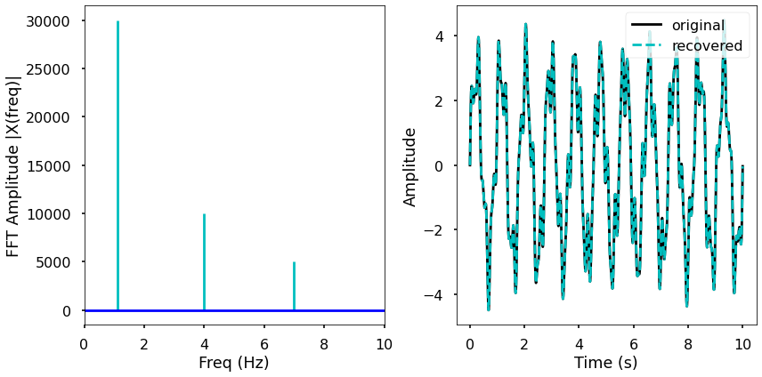

```python
srate = 2000 # Sampling rate
t = np.arange(0,10,1./srate) # Time

# Signal
freq1 = 1.1
x = 3*np.sin(2*np.pi*freq1*t)

freq2 = 4.0
x += np.sin(2*np.pi*freq2*t)

freq3 = 7.0
x += 0.5* np.sin(2*np.pi*freq3*t)

# FFT of the signal
X = fft(x)
N = len(X)
n = np.arange(N)
T = N/srate
freq = n/T

plt.figure(figsize = (12, 6))
plt.subplot(121)
plt.stem(freq, np.abs(X), 'c', markerfmt=" ", basefmt="-b")
plt.xlabel('Freq (Hz)')
plt.ylabel('FFT Amplitude |X(freq)|')
plt.xlim(0, 10)

plt.subplot(122)
plt.plot(t, x, 'k',label='original')
plt.plot(t, ifft(X), 'c--',label='recovered')
plt.xlabel('Time (s)')
plt.ylabel('Amplitude')
plt.tight_layout()
plt.legend()
plt.show()
```

#### Amplitude Spectrum

Two ways of getting the Amplitude Spectrum. Notice the difference in Y-axis values between the two. The second method produces the actual amplitude values that we initially used to generate the signals (3.0, 1.0, and 0.5 at the three frequencies respectively)

```
(0.0, 10.0)
```

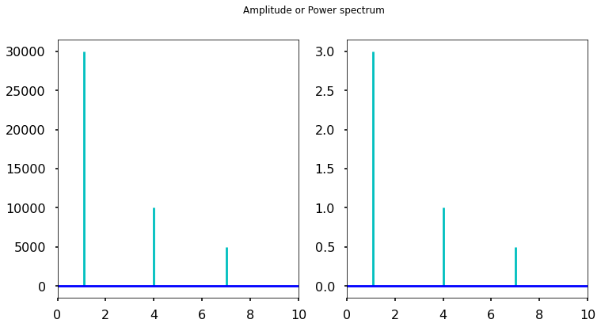

```python
# FFT of the signal (method 1)
X = fft(x)
N = len(X)
n = np.arange(N)
T = N/srate
freq = n/T

# FFT of the signal (method 2)
npnts  = len(t)
signal1D = 2*np.abs(fft(x,npnts)/npnts)
freqq = np.linspace(0,srate/2,int(np.floor(npnts/2)+1))

plt.figure(figsize = (12, 6))
plt.suptitle('Amplitude or Power spectrum');
plt.subplot(121)
plt.stem(freq, np.abs(X), 'c', markerfmt=" ", basefmt="-b")
plt.xlim([0,10])
plt.subplot(122)
plt.stem(freqq,signal1D[0:len(freqq)], 'c', markerfmt=" ", basefmt="-b")
plt.xlim([0,10])
```

#### Complex Signal

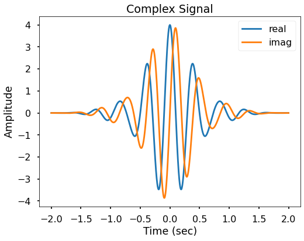

```python
srate = 2000 # Sampling rate in Hz
t = np.arange(-2.0, 2.0, 1./srate) # Time Vector in seconds

# Signal
freq1 = 2.4
cx = 3*np.exp(1j*(2*np.pi*freq1*t));

freq2 = 3.1
cx += np.exp(1j*(2*np.pi*freq2*t));

# multiply signal with a Gaussian
gauss  = np.exp( (-t**2) / 0.5)
csignal = np.multiply(cx,gauss)

plt.figure(figsize = (8,6))
plt.plot(t,np.real(csignal),label='real')
plt.plot(t,np.imag(csignal),label='imag')
plt.xlabel('Time (sec)'), plt.ylabel('Amplitude')
plt.title('Complex Signal')
plt.legend()
plt.show()
```

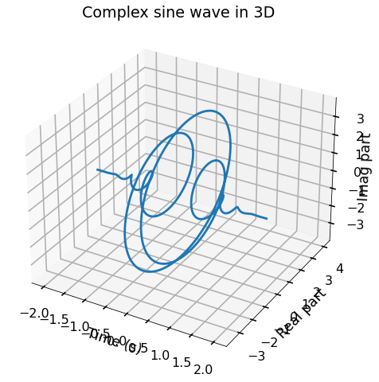

```python
# now show in 3D
fig = plt.figure(figsize = (12,8))
ax = fig.gca(projection='3d')
ax.plot(t,np.real(csignal),np.imag(csignal))
ax.set_xlabel('Time (s)'), ax.set_ylabel('Real part'), ax.set_zlabel('Imag part')
ax.set_title('Complex sine wave in 3D')
plt.show()
```

### 2D FFT (working with images)

#### 1. Blurring an image with 2D FFT

Adapted from the following [numpy example](https://scipython.com/book/chapter-6-numpy/examples/blurring-an-image-with-a-two-dimensional-fft/)

```python
tmp = scipy.misc.face(gray=True) #Racoon face from SciPy
image = tmp[128:640, 256:768]
image.shape
```

```
(512, 512)
```

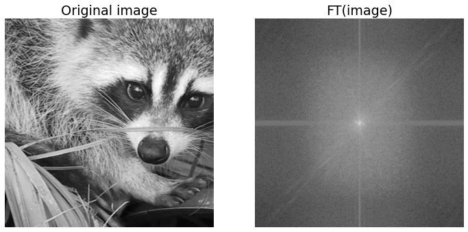

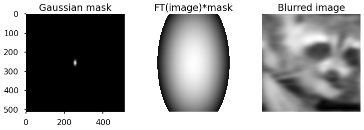

```python
plt.figure(figsize = (12, 6))
plt.subplot(121)
plt.title('Original image')
plt.axis('off')
plt.imshow(image,cmap='gray');

# Take the 2-dimensional FFT and center the frequencies
ftimage = fftn(image)
ftimage = fftshift(ftimage)

#ftimage = np.fft.fft2(image) #Numpy 2D FFT
#ftimage = np.fft.fftshift(ftimage)

plt.subplot(122)
#plt.imshow(np.abs(ftimage))
plt.imshow(np.log(np.abs(ftimage)), cmap='gray')
plt.title('FT(image)')
plt.axis('off')
plt.show()

# Build and apply a Gaussian filter
sigmax, sigmay = 7, 13
size = image.shape[0]
cy, cx = size/2, size/2
x = np.linspace(0, size, size)
y = np.linspace(0, size, size)
X, Y = np.meshgrid(x, y)
gmask = np.exp(-(((X-cx)/sigmax)**2 + ((Y-cy)/sigmay)**2))
#Note: mask is in Fourier space; same size as FT(image)

plt.figure(figsize = (12, 6))
plt.subplot(131)
plt.imshow(gmask, cmap='gray')
plt.title('Gaussian mask')

ftimagep = ftimage * gmask
plt.subplot(132)
plt.imshow(np.log(np.abs(ftimagep)),cmap='gray')
plt.title('FT(image)*mask')
plt.axis('off')

# Finally, take the inverse transform and show the blurred image
imagep = np.fft.ifft2(ftimagep)

plt.subplot(133)
plt.imshow(np.abs(imagep), cmap='gray')
plt.title('Blurred image')
plt.axis('off')
plt.show()
```

#### 2. Gaussian blur implemented using FFT convolution: `fftconvolve`

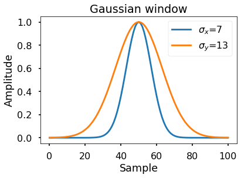

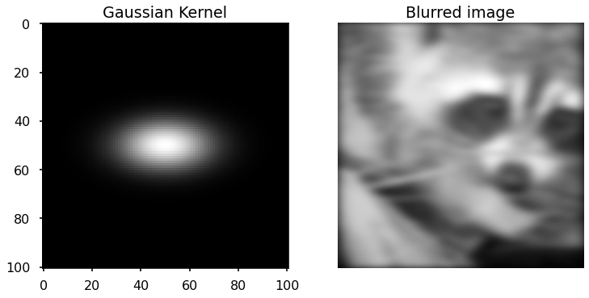

```python
#From https://docs.scipy.org/doc/scipy/reference/generated/scipy.signal.fftconvolve.html
window_x = signal.windows.gaussian(101, std=7)
window_y = signal.windows.gaussian(101, std=13)

plt.plot(window_x, label= "$\sigma_x$=7")
plt.plot(window_y, label= "$\sigma_y$=13")
plt.legend(loc="upper right")
plt.title("Gaussian window")
plt.ylabel("Amplitude")
plt.xlabel("Sample")

kernel = np.outer(window_x, window_y)
#Note: Kernel is in the same coordinate as the image; Its size is smaller compared to image

plt.figure(figsize = (12, 6))
plt.subplot(121)
plt.imshow(kernel, cmap='gray')
plt.title('Gaussian Kernel')

blurred = signal.fftconvolve(image, kernel, mode='same')

plt.subplot(122)
plt.imshow(blurred, cmap='gray')
plt.title('Blurred image')
plt.axis('off')
plt.show()
```

Notice the dark borders around the image, due to zero-padding beyond its boundaries.

#### 3. Gaussian blur using `SciPy.ndimage`

Adapted from the following [SciPy lecture](http://scipy-lectures.org/advanced/image_processing/auto_examples/plot_face_denoise.html)

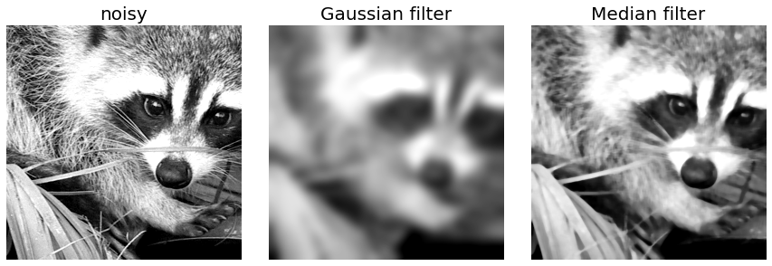

```python
# Image Denoising: Gaussian filter, Median filter
noisy = image + 0.4*image.std()*np.random.random(image.shape)

gauss_denoised = ndimage.gaussian_filter(noisy, sigma = 11)
med_denoised = ndimage.median_filter(noisy, size = 9)

plt.figure(figsize=(12,4))

plt.subplot(131)
plt.imshow(noisy, cmap=plt.cm.gray, vmin=40, vmax=220)
plt.axis('off')
plt.title('noisy', fontsize=20)
plt.subplot(132)
plt.imshow(gauss_denoised, cmap=plt.cm.gray, vmin=40, vmax=220)
plt.axis('off')
plt.title('Gaussian filter', fontsize=20)
plt.subplot(133)
plt.imshow(med_denoised, cmap=plt.cm.gray, vmin=40, vmax=220)
plt.axis('off')
plt.title('Median filter', fontsize=20)

plt.subplots_adjust(wspace=0.02, hspace=0.02, top=0.9, bottom=0, left=0, right=1)
plt.show()
```

Note that a Gaussian filter smooths out the noise and the edges. Median filter averages the noise and preserves the edges better

### `SciKit-Image`

Adapted from the following `SciKit-Image` [documentation](https://scikit-image.org/docs/stable/auto_examples/filters/plot_dog.html)

#### Band-pass filtering by Difference of Gaussians

Band-pass filters attenuate signal frequencies outside of a range (band) of interest. In image analysis, they can be used to denoise images while at the same time reducing low-frequency artifacts such a uneven illumination. Band-pass filters can be used to find image features such as blobs and edges.

One method for applying band-pass filters to images is to subtract an image blurred with a Gaussian kernel from a less-blurred image. This example shows two applications of the Difference of Gaussians approach for band-pass filtering.

More on DoG [here](https://towardsdatascience.com/computer-vision-feature-extraction-101-on-medical-images-part-3-difference-of-gaussian-and-b3cbe5c37415)

##### Denoise image and reduce shadows

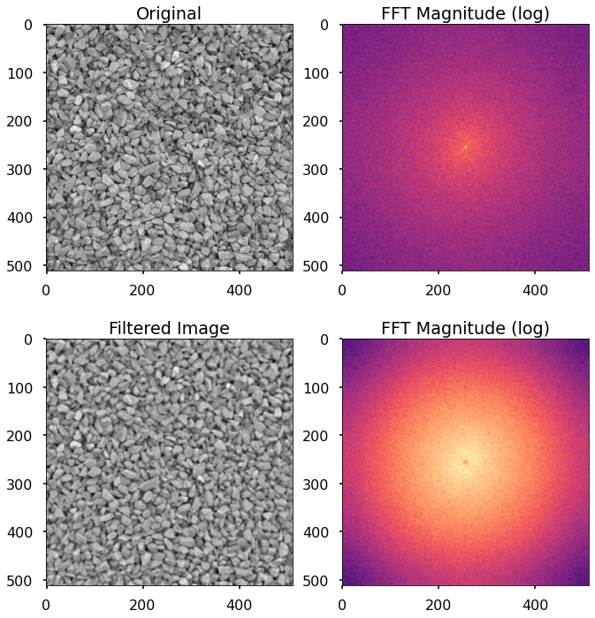

```python
image = gravel()
wimage = image * window('hann', image.shape)  # window image to improve FFT
filtered_image = difference_of_gaussians(image, 1, 12)
filtered_wimage = filtered_image * window('hann', image.shape)
im_f_mag = fftshift(np.abs(fftn(wimage)))
fim_f_mag = fftshift(np.abs(fftn(filtered_wimage)))

fig, ax = plt.subplots(nrows=2, ncols=2, figsize=(11, 12))
ax[0, 0].imshow(image, cmap='gray')
ax[0, 0].set_title('Original')
ax[0, 1].imshow(np.log(im_f_mag), cmap='magma')
ax[0, 1].set_title('FFT Magnitude (log)')
ax[1, 0].imshow(filtered_image, cmap='gray')
ax[1, 0].set_title('Filtered Image')
ax[1, 1].imshow(np.log(fim_f_mag), cmap='magma')
ax[1, 1].set_title('FFT Magnitude (log)')
plt.show()
```

##### Enhance edges in an image

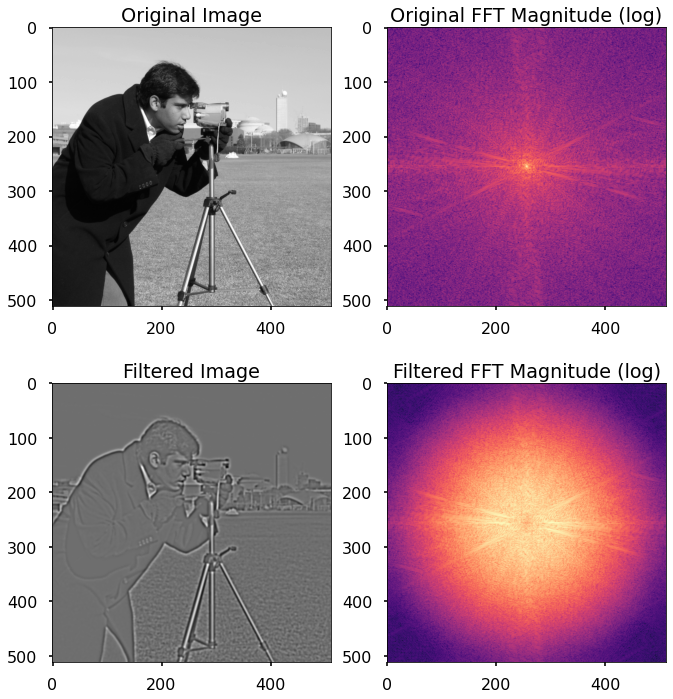

```python
image = camera()
#image = noisy
wimage = image * window('hann', image.shape)  # window image to improve FFT
filtered_image = difference_of_gaussians(image, 1.5)
filtered_wimage = filtered_image * window('hann', image.shape)
im_f_mag = fftshift(np.abs(fftn(wimage)))
fim_f_mag = fftshift(np.abs(fftn(filtered_wimage)))

fig, ax = plt.subplots(nrows=2, ncols=2, figsize=(11, 12))
ax[0, 0].imshow(image, cmap='gray')
ax[0, 0].set_title('Original Image')
ax[0, 1].imshow(np.log(im_f_mag), cmap='magma')
ax[0, 1].set_title('Original FFT Magnitude (log)')
ax[1, 0].imshow(filtered_image, cmap='gray')
ax[1, 0].set_title('Filtered Image')
ax[1, 1].imshow(np.log(fim_f_mag), cmap='magma')
ax[1, 1].set_title('Filtered FFT Magnitude (log)')
plt.show()
```